# Projet Actuariat Vie — Sujet 9

Influence du taux d’intérêt sur la Valeur Actuelle Probable (VAP) d’une rente viagère

Groupe 7

05 juin 2026

> **Contexte du projet.** Un assureur suédois détient un portefeuille de rentes viagères constitué d’une cohorte ayant souscrit en **2018** à l’âge de **75 ans**. La cohorte de naissance est donc $2018 - 75 = \mathbf{1943}$.  
> L’objectif est d’estimer la mortalité de cette cohorte à partir des données HMD, puis de calculer la VAP du contrat et d’analyser sa sensibilité au taux d’intérêt et aux variations de mortalité.

# 1 Packages et paramètres

## 1.1 Chargement des packages

```r
library(demography)        # Données HMD et modèles démographiques
library(StMoMo)            # Modèles de mortalité stochastique
library(lifecontingencies) # Calcul actuariel : rentes, capitaux, provisions
```

## 1.2 Paramètres globaux du projet

Les paramètres centraux sont définis ici pour pouvoir les modifier facilement si le sujet changeait de pays ou d’année de souscription.

```r
pays             <- "SWE"
label_pays       <- "Sweden"
annee_souscription <- 2018
age_souscription   <- 75
cohorte            <- annee_souscription - age_souscription  # = 1943
age_max            <- 110
seuil_IC           <- 0.90
z90                <- qnorm(1 - (1 - seuil_IC) / 2)         # quantile pour IC 90%

cat("Cohorte de naissance :", cohorte, "\n")
```

```
## Cohorte de naissance : 1943
```

```r
cat("Quantile z90 :", round(z90, 4), "\n")
```

```
## Quantile z90 : 1.6449
```

# 2 Téléchargement des données (HMD)

## 2.1 Données de la Suède

Les données de mortalité et d’exposition proviennent de la **Human Mortality Database** (HMD, www.mortality.org). La fonction `hmd.mx()` du package `demography` permet de les télécharger directement. On récupère :

- Les **taux de mortalité bruts** $\mu_{x,t} = D_{x,t} / E_{x,t}$ (taux centraux) ;
- Les **populations exposées au risque** $E_{x,t}$ (en nombre de personnes-années).

```r
swedenDemo <- hmd.mx(
  country  = pays,
  username = "marwen.jenane@esprit.tn",
  password = "Marwen26.",
  label    = label_pays
)

swedenExp <- hmd.pop(
  country  = pays,
  username = "marwen.jenane@esprit.tn",
  password = "Marwen26.",
  label    = label_pays
)
```

```r
print(swedenDemo)
```

```
## Mortality data for Sweden
##     Series: female male total
##     Years: 1751 - 2024
##     Ages:  0 - 110
```

# 3 Estimation des taux de mortalité par MV et intervalles de confiance

## 3.1 Extraction de la cohorte 1943

En lecture **transversale** (ou de cohorte), on suit les individus nés en 1943 : ils ont l’âge $x$ en l’année $1943 + x$. On extrait donc les taux $\mu_{x,\, 1943+x}$ depuis la matrice complète.

```r
annees <- swedenDemo$year
ages   <- swedenDemo$age
mx     <- swedenDemo$rate$total          # matrice (âge × année)
expo   <- swedenExp$pop$total

# Âges pour lesquels l'année calendaire (1943 + age) est disponible dans les données
ages_cohorte   <- ages[(cohorte + ages) %in% annees]
annees_cohorte <- cohorte + ages_cohorte

# Extraction des taux et expositions le long de la diagonale cohorte
mx_cohorte <- sapply(
  seq_along(ages_cohorte),
  function(i) mx[which(ages == ages_cohorte[i]),
                 which(annees == annees_cohorte[i])]
)

expo_cohorte <- sapply(
  seq_along(ages_cohorte),
  function(i) expo[which(ages == ages_cohorte[i]),
                   which(annees == annees_cohorte[i])]
)

cohort_data <- data.frame(
  Age  = ages_cohorte,
  Year = annees_cohorte,
  mx   = mx_cohorte,
  Expo = expo_cohorte
)

head(cohort_data)
```

|  | Age | Year | mx | Expo |
| --- | --- | --- | --- | --- |
| 1 | 0 | 1943 | 0.030814 | 111330 |
| 2 | 1 | 1944 | 0.003619 | 110621 |
| 3 | 2 | 1945 | 0.002041 | 110529 |
| 4 | 3 | 1946 | 0.001227 | 110555 |
| 5 | 4 | 1947 | 0.000900 | 110786 |
| 6 | 5 | 1948 | 0.000590 | 111134 |

## 3.2 Calcul des intervalles de confiance à 90 %

En supposant que le nombre de décès $D_{x,t}$ suit une loi de Poisson de paramètre $E_{x,t} \mu_{x,t}$ (approximation classique de la binomiale), l’estimateur MV du taux central est $\hat{\mu}_{x,t} = D_{x,t} / E_{x,t}$, d’écart-type asymptotique :
$$\widehat{\text{se}}(\hat{\mu}_{x,t}) =
\sqrt{\frac{\hat{\mu}_{x,t}}{E_{x,t}}}$$
L’intervalle de confiance à 90 % est alors :
$$\hat{\mu}_{x,t} \pm z_{0.95} \cdot \widehat{\text{se}}(\hat{\mu}_{x,t})$$

```r
erreur_std <- sqrt(mx_cohorte / expo_cohorte)

IC_inf <- pmax(0, mx_cohorte - z90 * erreur_std)
IC_sup <- mx_cohorte + z90 * erreur_std
```

## 3.3 Tracé — Taux de mortalité (cohorte complète)

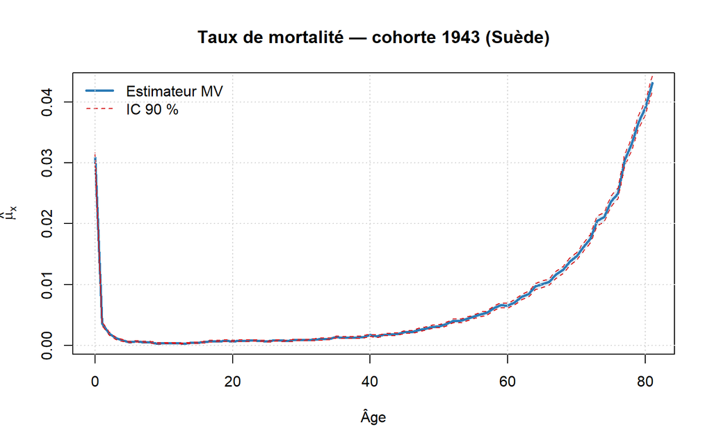

```r
plot(
  ages_cohorte, mx_cohorte,
  type = "l", lwd = 2.5, col = "#2c7bb6",
  xlab = "Âge", ylab = expression(hat(mu)[x]),
  main = paste0("Taux de mortalité — cohorte ", cohorte, " (Suède)")
)
polygon(
  c(ages_cohorte, rev(ages_cohorte)),
  c(IC_sup, rev(IC_inf)),
  col = adjustcolor("#2c7bb6", alpha.f = 0.15), border = NA
)
lines(ages_cohorte, IC_inf, lty = 2, col = "#d7191c")
lines(ages_cohorte, IC_sup, lty = 2, col = "#d7191c")
legend("topleft",
  legend = c("Estimateur MV", "IC 90 %"),
  lty = c(1, 2), lwd = c(2.5, 1),
  col = c("#2c7bb6", "#d7191c"), bty = "n"
)
grid()
```

## 3.4 Tracé — à partir de l’âge de souscription (75 ans)

On restreint l’analyse aux âges $\geq 75$ ans, qui correspondent à la durée contractuelle effective de la rente.

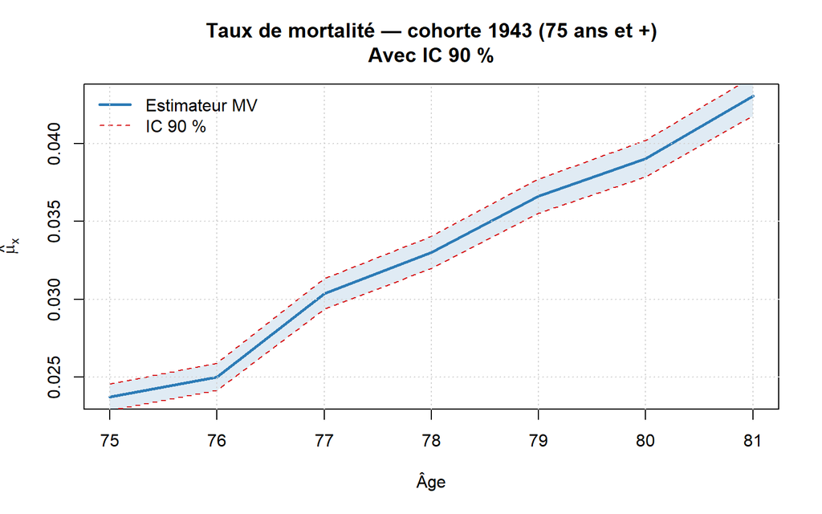

```r
idx75 <- ages_cohorte >= age_souscription

plot(
  ages_cohorte[idx75], mx_cohorte[idx75],
  type = "l", lwd = 2.5, col = "#2c7bb6",
  xlab = "Âge", ylab = expression(hat(mu)[x]),
  main = paste0("Taux de mortalité — cohorte ", cohorte,
                " (75 ans et +)\nAvec IC 90 %")
)
polygon(
  c(ages_cohorte[idx75], rev(ages_cohorte[idx75])),
  c(IC_sup[idx75], rev(IC_inf[idx75])),
  col = adjustcolor("#2c7bb6", alpha.f = 0.15), border = NA
)
lines(ages_cohorte[idx75], IC_inf[idx75], lty = 2, col = "#d7191c")
lines(ages_cohorte[idx75], IC_sup[idx75], lty = 2, col = "#d7191c")
legend("topleft",
  legend = c("Estimateur MV", "IC 90 %"),
  lty = c(1, 2), lwd = c(2.5, 1),
  col = c("#2c7bb6", "#d7191c"), bty = "n"
)
grid()
```

# 4 Log-taux de mortalité historiques (cohorte 1943)

La fonction `extractCohort()` extrait la **diagonale cohorte** directement depuis la matrice des log-taux. Cette représentation logarithmique est préférée car, conformément à la **loi de Gompertz**, le log-taux de mortalité est approximativement linéaire en l’âge :
$$\ln \mu_x \approx \alpha + \beta x$$

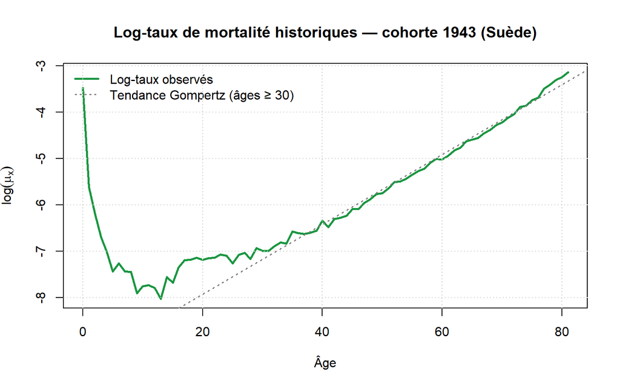

```r
logmx        <- log(swedenDemo$rate$total)
logmx_cohort <- extractCohort(logmx, cohort = cohorte)

plot(
  ages_cohorte, logmx_cohort,
  type = "l", lwd = 2.5, col = "#1a9641",
  xlab = "Âge", ylab = expression(log(mu[x])),
  main = paste0("Log-taux de mortalité historiques — cohorte ", cohorte, " (Suède)")
)
abline(lm(logmx_cohort[ages_cohorte >= 30] ~ ages_cohorte[ages_cohorte >= 30]),
       lty = 3, col = "gray50", lwd = 1.5)
legend("topleft",
  legend = c("Log-taux observés", "Tendance Gompertz (âges ≥ 30)"),
  lty = c(1, 3), lwd = c(2.5, 1.5),
  col = c("#1a9641", "gray50"), bty = "n"
)
grid()
```

> **Interprétation.** On retrouve le profil caractéristique de la mortalité humaine décrit dans le cours (Chapitre 1) :
> 1. **Forte mortalité infantile** (âges 0–2), reflétant les risques périnataux.
> 2. **Minimum de mortalité** autour de 10–15 ans.
> 3. **Croissance quasi-linéaire** aux âges adultes et élevés, conforme à la loi de Gompertz : $\mu_x = \alpha e^{\beta x}$. Ce comportement est précisément exploité par les modèles prospectifs de type Lee-Carter.

# 5 Calcul de la VAP à la date de souscription

## 5.1 Construction de la table de mortalité

On convertit les taux centraux $\mu_x$ en probabilités annuelles de décès $q_x$ sous l’hypothèse de **constance du taux de mortalité** dans l’année, recommandée en contexte de rente (Chapitre 1 du cours) :
$$q_x = 1 - e^{-\mu_x}, \qquad p_x = 1 - q_x$$

```r
# Restriction aux âges à partir de 75 ans (date de souscription)
mx75   <- mx_cohorte[idx75]
ages75 <- ages_cohorte[idx75]

qx75 <- 1 - exp(-mx75)
px75 <- 1 - qx75
px75[length(px75)] <- 0
table_mort <- data.frame(
  Age = ages75,
  mx  = round(mx75,  6),
  qx  = round(qx75,  6),
  px  = round(px75,  6)
)

head(table_mort, 10)
```

|  | Age | mx | qx | px |
| --- | --- | --- | --- | --- |
| 1 | 75 | 0.023722 | 0.023443 | 0.976557 |
| 2 | 76 | 0.025008 | 0.024698 | 0.975302 |
| 3 | 77 | 0.030360 | 0.029904 | 0.970096 |
| 4 | 78 | 0.033008 | 0.032469 | 0.967531 |
| 5 | 79 | 0.036623 | 0.035960 | 0.964040 |
| 6 | 80 | 0.039047 | 0.038294 | 0.961706 |
| 7 | 81 | 0.043049 | 0.042136 | 0.000000 |

## 5.2 Fonctions de calcul de la VAP

La **valeur actuelle probable (VAP)** d’une rente viagère est définie dans le cours (Chapitre 3) comme :
$$\ddot{a}_x = \sum_{k=0}^{\infty} v^k \cdot {}_k p_x$$
où $v = (1+i)^{-1}$ est le facteur d’actualisation et ${}_k p_x$ la probabilité de survie jusqu’à l’âge $x+k$.

Pour une **rente temporaire** de $n$ années :
$${}_{|n}\ddot{a}_x = \sum_{k=0}^{n-1} v^k \cdot {}_k p_x$$

```r
# Probabilité de survie depuis le début (âge 75)
kpx <- function(k, px_vect) {
  if (k == 0) return(1)
  prod(px_vect[1:k])
}

VAP_viagere <- function(i, px_vect){
  v <- 1/(1+i)

  surv <- c(1, cumprod(px_vect))
  surv <- surv[1:length(px_vect)]

  sum(v^(0:(length(surv)-1)) * surv)
}

VAP_temp15 <- function(i, px_vect){
  v <- 1/(1+i)

  surv <- c(1, cumprod(px_vect))
  surv <- surv[1:15]

  sum(v^(0:14) * surv)
}
```

## 5.3 Calcul de la VAP pour le taux de référence

On choisit un taux technique de référence $i = 2\%$, conformément aux pratiques actuarielles courantes en assurance vie.

```r
i_ref <- 0.02

vap_vg_ref  <- VAP_viagere(i_ref, px75)
vap_t15_ref <- VAP_temp15(i_ref, px75)

cat("=== VAP à i =", i_ref * 100, "% ===\n")
```

```
## === VAP à i = 2 % ===
```

```r
cat("Rente viagère à termes anticipés  :", round(vap_vg_ref,  4), "\n")
```

```
## Rente viagère à termes anticipés  : 6.0859
```

```r
cat("Rente temporaire 15 ans           :", round(vap_t15_ref, 4), "\n")
```

```
## Rente temporaire 15 ans           : NA
```

# 6 Sensibilité de la VAP au taux d’intérêt

## 6.1 Calcul sur une grille de taux

On fait varier le taux d’intérêt $i$ de 0 % à 10 % et on observe l’effet sur les deux VAP. Cette analyse de sensibilité est centrale en gestion actif-passif (ALM) : les rentes viagères sont des engagements à très longue durée, donc particulièrement sensibles aux variations de taux.

```r
taux        <- seq(0, 0.10, by = 0.005)
vap_viagere <- sapply(taux, function(i) VAP_viagere(i, px75))
vap_temp15  <- sapply(taux, function(i) VAP_temp15(i, px75))
```

## 6.2 Graphique de sensibilité

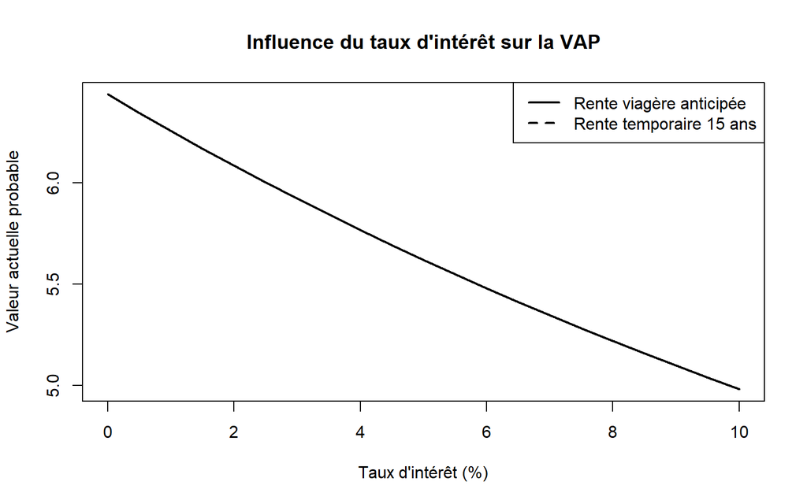

```r
plot(
  taux * 100,
  vap_viagere,
  type = "l",
  lwd = 2,
  xlab = "Taux d'intérêt (%)",
  ylab = "Valeur actuelle probable",
  main = "Influence du taux d'intérêt sur la VAP"
)

lines(
  taux * 100,
  vap_temp15,
  lwd = 2,
  lty = 2
)

legend(
  "topright",
  legend = c(
    "Rente viagère anticipée",
    "Rente temporaire 15 ans"
  ),
  lty = c(1,2),
  lwd = c(2,2)
)
```

## 6.3 Tableau récapitulatif

```r
df_sens <- data.frame(
  "Taux i (%)"            = taux * 100,
  "VAP rente viagère"     = round(vap_viagere, 3),
  "VAP rente temp. 15 ans"= round(vap_temp15,  3),
  "Écart relatif (%)"     = round((vap_viagere - vap_temp15) / vap_viagere * 100, 1),
  check.names = FALSE
)
df_sens
```

| Taux i (%) | VAP rente viagère | VAP rente temp. 15 ans | Écart relatif (%) |
| --- | --- | --- | --- |
| 0.0 | 6.438 | NA | NA |
| 0.5 | 6.346 | NA | NA |
| 1.0 | 6.257 | NA | NA |
| 1.5 | 6.170 | NA | NA |
| 2.0 | 6.086 | NA | NA |
| 2.5 | 6.004 | NA | NA |
| 3.0 | 5.923 | NA | NA |
| 3.5 | 5.845 | NA | NA |
| 4.0 | 5.768 | NA | NA |
| 4.5 | 5.694 | NA | NA |

[output cut: 11 more lines]

# 7 Comparaison : taux d’intérêt vs variation de la mortalité

## 7.1 Mise en place du scénario de stress mortalité

On considère plusieurs **chocs de mortalité** : une amélioration de 10 % et 20 % (scénarios de longévité, défavorables pour l’assureur de rentes) ainsi qu’une dégradation de 10 % (favorable). On compare l’effet de ces chocs à celui d’une variation du taux d’intérêt de ±1 point.

```r
# Scénarios de mortalité
scenarios <- list(
  "Mortalité +10 % (dégradation)" = 1.10 * mx75,
  "Mortalité observée (base)"     =        mx75,
  "Mortalité -10 % (amélioration)"= 0.90 * mx75,
  "Mortalité -20 % (fort amélio.)"= 0.80 * mx75
)

# Calcul des VAP pour chaque scénario à i = 2 %
vap_scenarios <- sapply(scenarios, function(mx_s) {
  px_s <- 1 - (1 - exp(-mx_s))
  VAP_viagere(i_ref, px_s)
})

# Effet d'une variation de ±1 pp sur le taux d'intérêt
vap_i_moins1 <- VAP_viagere(i_ref - 0.01, px75)  # i = 1 %
vap_i_plus1  <- VAP_viagere(i_ref + 0.01, px75)  # i = 3 %
```

## 7.2 Graphique comparatif

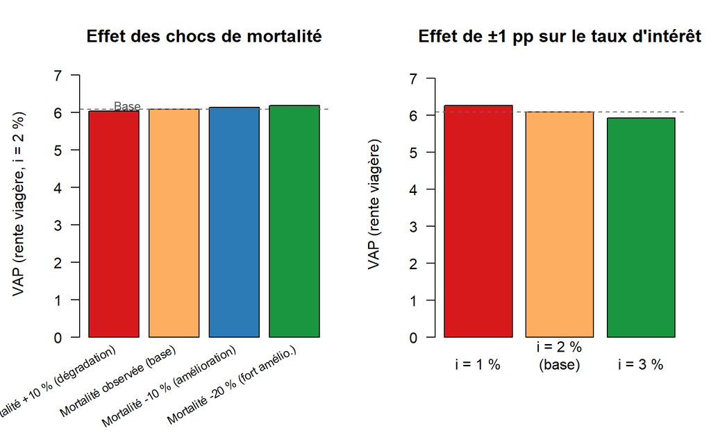

```r
par(mfrow = c(1, 2), mar = c(6, 4.5, 4, 1.5))

# --- Effet mortalité ---
couleurs_mort <- c("#d7191c", "#fdae61", "#2c7bb6", "#1a9641")
bp <- barplot(
  vap_scenarios,
  col    = couleurs_mort,
  names.arg = rep("", length(vap_scenarios)),
  ylab   = "VAP (rente viagère, i = 2 %)",
  main   = "Effet des chocs de mortalité",
  ylim   = c(0, max(vap_scenarios) * 1.15),
  las    = 1
)
text(bp, par("usr")[3] - 0.3,
     labels = names(vap_scenarios),
     srt = 30, adj = 1, xpd = TRUE, cex = 0.78)
abline(h = vap_scenarios["Mortalité observée (base)"],
       lty = 2, col = "gray40")
text(bp[1], vap_scenarios["Mortalité observée (base)"] + 0.1,
     "Base", col = "gray30", cex = 0.8, adj = 0)

# --- Effet taux d'intérêt ---
vap_taux_3pts <- c(
  vap_i_moins1,
  vap_vg_ref,
  vap_i_plus1
)
labels_taux <- c("i = 1 %", "i = 2 %\n(base)", "i = 3 %")
couleurs_taux <- c("#d7191c", "#fdae61", "#1a9641")

barplot(
  vap_taux_3pts,
  col    = couleurs_taux,
  names.arg = labels_taux,
  ylab   = "VAP (rente viagère)",
  main   = "Effet de ±1 pp sur le taux d'intérêt",
  ylim   = c(0, max(vap_taux_3pts) * 1.15),
  las    = 1
)
abline(h = vap_vg_ref, lty = 2, col = "gray40")
```

## 7.3 Tableau synthétique des impacts

```r
# Variations relatives par rapport à la situation de base
base <- vap_vg_ref

resultats <- data.frame(
  "Scénario" = c(
    "Mortalité +10 % (dégradation)",
    "Mortalité de base (référence)",
    "Mortalité −10 % (amélioration)",
    "Mortalité −20 % (fort amélioration)",
    "Taux d'intérêt i = 1 % (−1 pp)",
    "Taux d'intérêt i = 2 % (base)",
    "Taux d'intérêt i = 3 % (+1 pp)"
  ),
  "VAP" = round(c(
    vap_scenarios,
    vap_i_moins1,
    vap_vg_ref,
    vap_i_plus1
  ), 3),
  "Variation vs base (%)" = round(c(
    (vap_scenarios - base) / base * 100,
    (vap_i_moins1 - base)  / base * 100,
    0,
    (vap_i_plus1  - base)  / base * 100
  ), 1),
  check.names = FALSE
)

resultats
```

| Scénario | VAP | Variation vs base (%) |
| --- | --- | --- |
| Mortalité +10 % (dégradation) | 6.038 | -0.8 |
| Mortalité de base (référence) | 6.086 | 0.0 |
| Mortalité −10 % (amélioration) | 6.135 | 0.8 |
| Mortalité −20 % (fort amélioration) | 6.184 | 1.6 |
| Taux d'intérêt i = 1 % (−1 pp) | 6.257 | 2.8 |
| Taux d'intérêt i = 2 % (base) | 6.086 | 0.0 |
| Taux d'intérêt i = 3 % (+1 pp) | 5.923 | -2.7 |

## 7.4 Discussion et conclusion

> **Conclusions de l’analyse de sensibilité.**

> **Taux d’intérêt.** Une baisse de 1 point de pourcentage du taux $i$ (de 2 % à 1 %) entraîne une hausse de la VAP de **2.8 %**, tandis qu’une hausse à 3 % la fait baisser de **2.7 %**. L’impact est asymétrique : les baisses de taux sont plus pénalisantes que les hausses ne sont favorables.

> **Mortalité.** Une amélioration de 10 % des taux de mortalité (scénario de longévité) augmente la VAP de **0.8 %** environ, et une amélioration de 20 % de **1.6 %**. Cet effet est **moins immédiat** que celui du taux d’intérêt, mais il se cumule dans le temps : il reflète le **risque de longévité**, qui est une préoccupation croissante pour les assureurs de rentes.

> **En résumé**, sur un horizon court, le **taux d’intérêt est le facteur dominant**. Sur un horizon long (et pour des cohortes de plus en plus âgées), le **risque de longévité** devient déterminant. Ces deux risques sont d’ailleurs liés en pratique : les périodes de bas taux coïncident souvent avec une meilleure espérance de vie, ce qui amplifie la fragilité du bilan de l’assureur.